# Prediksi Kasus ISPA di Jakarta Berdasarkan Kualitas Udara dan Faktor Meteorologi

### B.5.2. Fig 2 - Distribution of Air Quality and Meteorological Variables in Jakarta

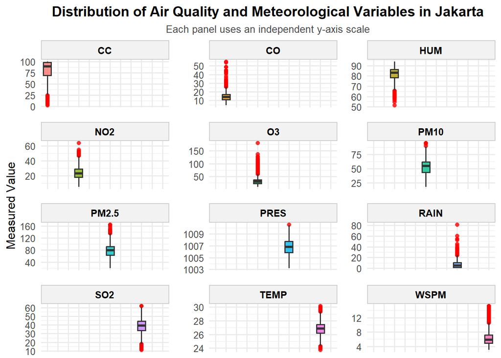

```r
# Visualisasi distribusi variabel polusi udara dan meteorologi di jakarta (Harian)
data_visualisasi <- ispu_cuaca_harian %>%
  pivot_longer(
    cols = c(PM2.5, PM10, SO2, CO, O3, NO2, TEMP, RAIN, HUM, WSPM, CC, PRES),
    names_to = "Variable",
    values_to = "Value"
  )

ggplot(data_visualisasi, aes(x = Variable, y = Value, fill = Variable)) +
  geom_boxplot(alpha = 0.8, outlier.colour = "red", outlier.shape = 16) +

  facet_wrap(~ Variable, scales = "free_y", ncol = 3) +

  labs(
    title = "Distribution of Air Quality and Meteorological Variables in Jakarta",
    subtitle = "Each panel uses an independent y-axis scale",
    x = NULL,
    y = "Measured Value"
  ) +

  theme_minimal(base_size = 12) +
  theme(
    plot.title = element_text(face = "bold", size = 14, hjust = 0.5),
    plot.subtitle = element_text(size = 10, color = "gray30", hjust = 0.5),

    strip.background = element_rect(fill = "gray95", color = "gray80"),
    strip.text = element_text(face = "bold", color = "black"),

    axis.text.x = element_blank(),
    axis.ticks.x = element_blank(),

    legend.position = "none",

    panel.spacing = unit(1, "lines")
  )
```

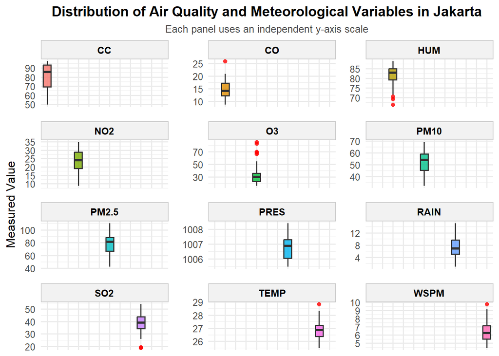

```r
# Visualisasi distribusi variabel polusi udara dan meteorologi di jakarta (Bulanan)
data_visualisasi_bulanan <- data_bulanan %>%
  pivot_longer(
    cols = c(PM2.5, PM10, SO2, CO, O3, NO2, TEMP, RAIN, HUM, WSPM, CC, PRES),
    names_to = "Variable",
    values_to = "Value"
  )

ggplot(data_visualisasi_bulanan, aes(x = Variable, y = Value, fill = Variable)) +
  geom_boxplot(alpha = 0.8, outlier.colour = "red", outlier.shape = 16) +

  facet_wrap(~ Variable, scales = "free_y", ncol = 3) +

  labs(
    title = "Distribution of Air Quality and Meteorological Variables in Jakarta",
    subtitle = "Each panel uses an independent y-axis scale",
    x = NULL,
    y = "Measured Value"
  ) +

  theme_minimal(base_size = 12) +
  theme(
    plot.title = element_text(face = "bold", size = 14, hjust = 0.5),
    plot.subtitle = element_text(size = 10, color = "gray30", hjust = 0.5),

    strip.background = element_rect(fill = "gray95", color = "gray80"),
    strip.text = element_text(face = "bold", color = "black"),

    axis.text.x = element_blank(),
    axis.ticks.x = element_blank(),

    legend.position = "none",

    panel.spacing = unit(1, "lines")
  )
```

# Bagian C. Feature Engineering

## C.1. Mengecek Nilai Skewness

```r
# Menghitung nilai skewness untuk setiap variabel
var_numerik <- data_bulanan[, c("PM2.5", "PM10", "SO2", "CO", "O3", "NO2",
                                  "TEMP", "RAIN", "HUM", "CC", "WSPM", "PRES",
                                  "Case_ISPA")]

nil_skewness <- sapply(var_numerik, skewness, na.rm = TRUE)
print(nil_skewness)
```

```
##      PM2.5       PM10        SO2         CO         O3        NO2       TEMP
## -0.2867486 -0.3818343 -0.3108963  0.6671965  1.6953418 -0.1746278  0.3567079
##       RAIN        HUM         CC       WSPM       PRES  Case_ISPA
##  0.1397578 -1.1693534 -0.4968726  0.7287102  0.1522115  0.1962142
```

Terlihat nilai skewness ada beberapa variabel yang bernilai > 0.5 atau > -0.5, jadi variabel tersebut akan dilakukan log transformasi

```r
library(MASS)
```

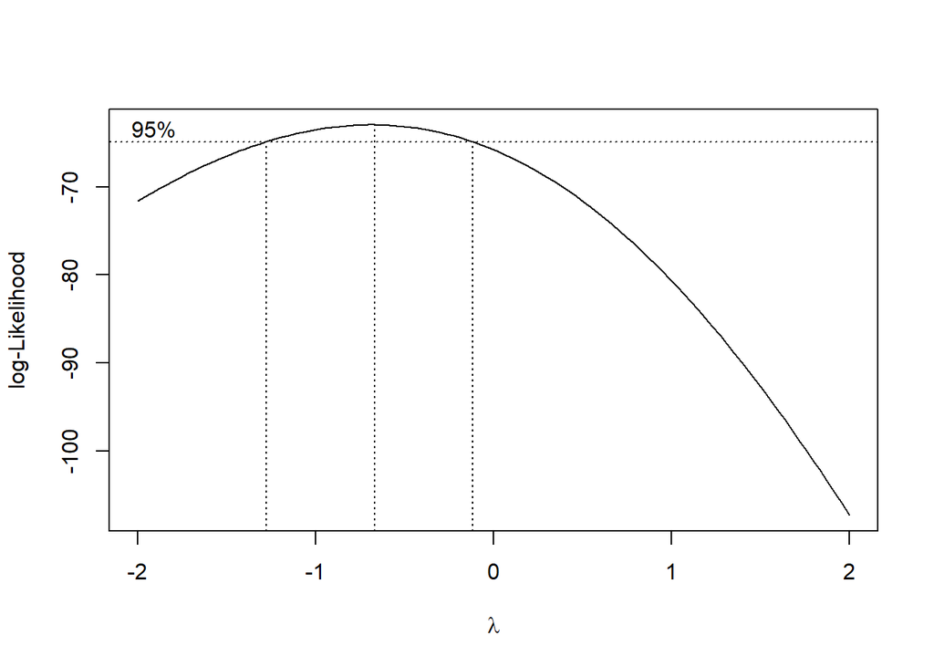

```r
boxcox_model <- boxcox(O3 ~ 1, data = data_bulanan)
```

```r
lambda <- boxcox_model$x[which.max(boxcox_model$y)]
```

```r
# Melakukan log transformation pada variabel yang nilai skewness > 0.5 atau > -0.5
data_bulanan$log_CO <- base::log(data_bulanan$CO)
data_bulanan$log_O3 <- (data_bulanan$O3^lambda-1) / lambda
data_bulanan$log_HUM <- (data_bulanan$HUM)^2
data_bulanan$log_WSPM <- base::log(data_bulanan$WSPM)
data_bulanan$ispa_log <- base::log(data_bulanan$Case_ISPA)
```

```r
# Mengecek kembali nilai skewness
skewness(data_bulanan$log_CO)
```

```
## [1] 0.04401122
```

```r
skewness(data_bulanan$log_O3)
```

```
## [1] 0.05130394
```

```r
skewness(data_bulanan$log_HUM)
```

```
## [1] -1.028737
```

```r
skewness(data_bulanan$log_WSPM)
```

```
## [1] 0.3421519
```

```r
skewness(data_bulanan$ispa_log)
```

```
## [1] -0.6852072
```

Disini nilai skewness pada variabel kelembaban masih tinggi, sekarang mengubah teknik data transformation

```r
data_bulanan$log_HUM <- sqrt(89 - data_bulanan$HUM)
```

```r
# Cek nilai skewness pada log_HUM
skewness(data_bulanan$log_HUM)
```

```
## [1] 0.36842
```

## C.2. Variabel Temporal: trend, season

Variabel Temporal dibuat untuk menganalisis apakah terdapat keterkaitan dengan tren dan musim pada kasus penelitian tersebut.

```r
# Variabel Trend
data_bulanan$Trend <- 1:nrow(data_bulanan)

# Variabel Season
data_bulanan$Season <- ifelse(
data_bulanan$Trend %in% c(1,2,3,4,11,12,13,14,15,16,23,24,25,26,27,28,35,36,37,38,39,40,47,48,49,50,51,52,59,60),
  1,
  0
)
```

## C.3. Variabel Lag: ispa_lag1

```r
data_bulanan$ispa_lag1 <- lag(data_bulanan$ispa_log, n = 1)

# Baris Pertama akan bernilai NA karena tidak ada bulan sebelumnya sehingga data akan dibuang
data_bulanan <- data_bulanan[!is.na(data_bulanan$ispa_lag1), ]
```

## C.4. Standarisasi Z-Score untuk Prediktor Kontinu

```r
data_bulanan$PM2.5_z <- scale(data_bulanan$PM2.5)
data_bulanan$PM10_z <- scale(data_bulanan$PM10)
data_bulanan$SO2_z <- scale(data_bulanan$SO2)
data_bulanan$CO_z <- scale(data_bulanan$log_CO)
data_bulanan$O3_z <- scale(data_bulanan$log_O3)
data_bulanan$NO2_z <- scale(data_bulanan$NO2)
data_bulanan$TEMP_z <- scale(data_bulanan$TEMP)
data_bulanan$RAIN_z <- scale(data_bulanan$RAIN)
data_bulanan$HUM_z <- scale(data_bulanan$log_HUM)
data_bulanan$WSPM_z <- scale(data_bulanan$log_WSPM)
data_bulanan$CC_z <- scale(data_bulanan$CC)
data_bulanan$PRES_z <- scale(data_bulanan$PRES)
```

Mengecek kembali nilai skewness setelah variabel sudah dilakukan transformasi nilai-z

```r
# Menghitung nilai skewness untuk setiap variabel
var_numerik2 <- data_bulanan[, c("PM2.5_z", "PM10_z", "SO2_z", "CO_z", "O3_z", "NO2_z",
                                  "TEMP_z", "RAIN_z", "HUM_z", "CC_z", "WSPM_z", "PRES_z",
                                  "Case_ISPA")]

nil_skewness2 <- sapply(var_numerik2, skewness, na.rm = TRUE)
print(nil_skewness2)
```

```
##     PM2.5_z      PM10_z       SO2_z        CO_z        O3_z       NO2_z
## -0.32646527 -0.42431506 -0.17179769  0.05488530  0.08582265 -0.04502046
##      TEMP_z      RAIN_z       HUM_z        CC_z      WSPM_z      PRES_z
##  0.41479260  0.11039456  0.40493424 -0.47784806  0.38167013  0.12129098
##   Case_ISPA
##  0.19792916
```

# Bagian D. Predictor Screening

## D.1. Chronological Train-Test Split

Split dilakukan secara proporsional (80% training / 20% testing) mengikuti urutan waktu, supaya kode tetap valid berapa pun jumlah baris data akhirnya (tidak bergantung pada indeks baris yang dihardcode).

```r
n_total <- nrow(data_bulanan)
n_train <- floor(0.8 * n_total)

train_data <- data_bulanan[1:n_train, ]
test_data  <- data_bulanan[(n_train + 1):n_total, ]
```

## D.2. Pearson Correlation Analysis

```r
library(corrplot)
```

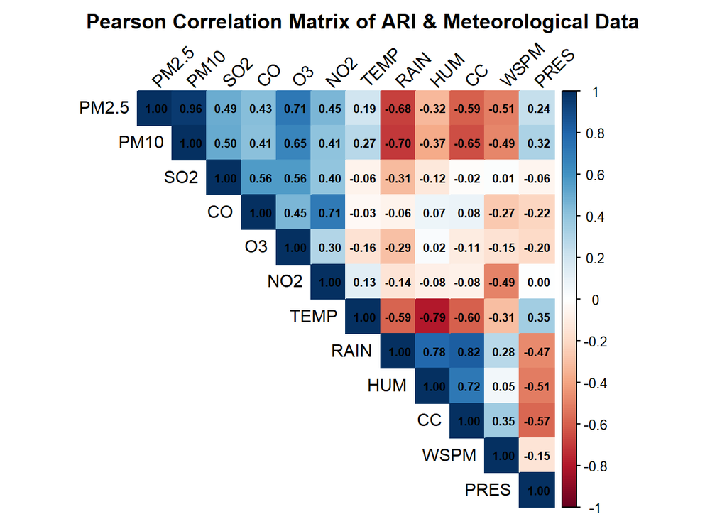

```r
# Analisis Korelasi Pearson dengan data bulanan yang belum dilakukan transformasi nilai-z dan tidak ada variabel tambahan
predictor_vars <- data_bulanan[, c(
  "PM2.5", "PM10", "SO2", "CO", "O3", "NO2",
  "TEMP", "RAIN", "HUM", "CC", "WSPM", "PRES"
)]

matrix_cor <- cor(predictor_vars, method = "pearson")

corrplot(matrix_cor,
         method = "color",
         type = "upper",
         addCoef.col = "black",
         number.cex = 0.7,
         tl.col = "black",
         tl.srt = 45,
         title = "Pearson Correlation Matrix of ARI & Meteorological Data",
         mar = c(0,0,2,0))
```

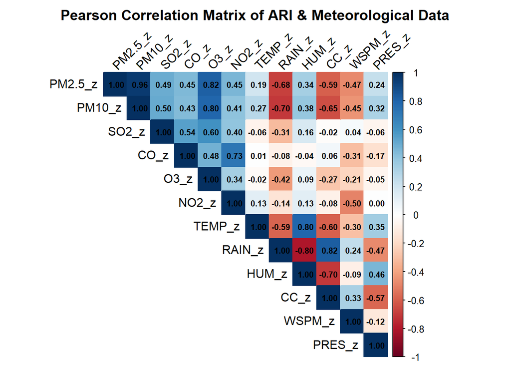

```r
# Analisis Korelasi Pearson dengan data bulanan yang sudah dilakukan transformasi nilai-z dan tidak ada variabel tambahan
predictor_vars2 <- data_bulanan[, c(
  "PM2.5_z", "PM10_z", "SO2_z", "CO_z", "O3_z", "NO2_z",
  "TEMP_z", "RAIN_z", "HUM_z", "CC_z", "WSPM_z", "PRES_z"
)]

matrix_cor2 <- cor(predictor_vars2, method = "pearson")

corrplot(matrix_cor2,
         method = "color",
         type = "upper",
         addCoef.col = "black",
         number.cex = 0.7,
         tl.col = "black",
         tl.srt = 45,
         title = "Pearson Correlation Matrix of ARI & Meteorological Data",
         mar = c(0,0,2,0))
```

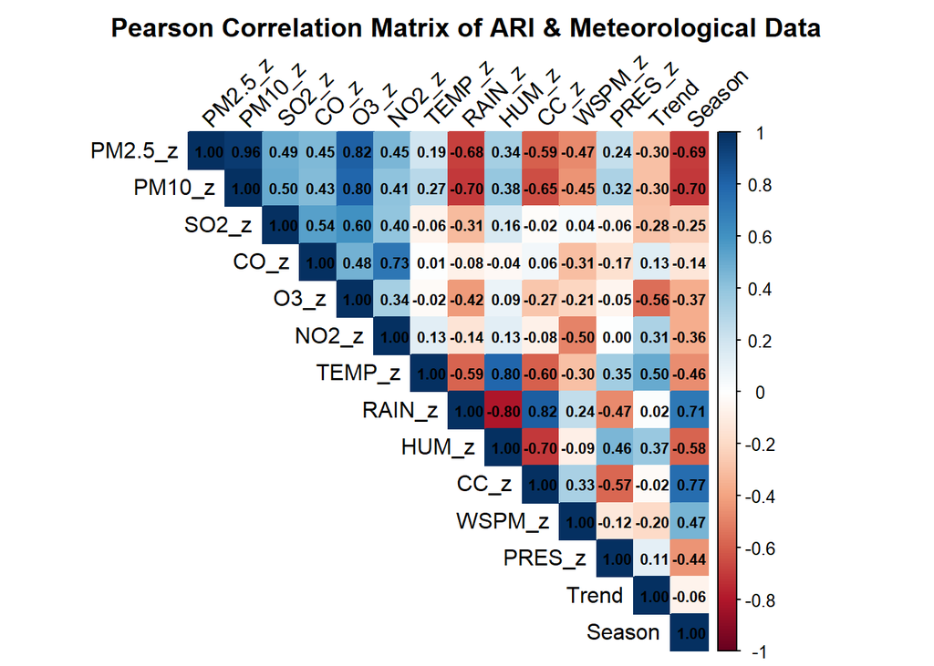

```r
# Analisis Korelasi Pearson dengan data bulanan yang sudah dilakukan transformasi nilai-z dan variabel temporal
predictor_vars3 <- data_bulanan[, c(
  "PM2.5_z", "PM10_z", "SO2_z", "CO_z", "O3_z", "NO2_z",
  "TEMP_z", "RAIN_z", "HUM_z", "CC_z", "WSPM_z", "PRES_z",
  "Trend", "Season"
)]

matrix_cor3 <- cor(predictor_vars3, method = "pearson")

corrplot(matrix_cor3,
         method = "color",
         type = "upper",
         addCoef.col = "black",
         number.cex = 0.7,
         tl.col = "black",
         tl.srt = 45,
         title = "Pearson Correlation Matrix of ARI & Meteorological Data",
         mar = c(0,0,2,0))
```

## D.3. Variance Inflation Factor (VIF)

```r
# Melakukan analisis dengan model linear regression untuk melihat hubungan setiap variabel dari nilai VIF
vif_model <- lm(
  Case_ISPA ~ PM2.5_z + PM10_z + SO2_z + CO_z + O3_z + NO2_z +
    TEMP_z + RAIN_z + HUM_z + WSPM_z + CC_z + PRES_z,
  data = train_data
)

vif(vif_model)
```

```
##   PM2.5_z    PM10_z     SO2_z      CO_z      O3_z     NO2_z    TEMP_z    RAIN_z
## 43.703504 27.435484  3.312705  4.126435  6.876194  4.993492  6.125749 11.696047
##     HUM_z    WSPM_z      CC_z    PRES_z
## 13.133938  2.533841  6.828006  2.024544
```

# Bagian E. Model Development: GAM

## E.1. Kandidat Formula GAM

```r
library(mgcv)
```

```r
f1_gam <- Case_ISPA ~
  s(PM2.5_z, k = 4) + s(PM10_z, k = 4) + s(SO2_z, k = 4) + s(CO_z, k = 4) +
  s(O3_z, k = 4) + s(NO2_z, k = 4) + s(TEMP_z, k = 4) + s(RAIN_z, k = 4) +
  s(HUM_z, k = 4) + s(WSPM_z, k = 4) + s(CC_z, k = 4) + s(PRES_z, k = 4) +
  Trend + Season + ispa_lag1

# Input F1
f2_gam <- Case_ISPA ~
  s(PM2.5_z, k = 4) + s(O3_z, k = 4) + s(TEMP_z, k = 4) + s(HUM_z, k = 4) +
  s(WSPM_z, k = 4) + s(PRES_z, k = 4) + ispa_lag1

# Input F2
f3_gam <- Case_ISPA ~
  s(PM2.5_z, k = 4) + s(O3_z, k = 4) + s(TEMP_z, k = 4) + s(WSPM_z, k = 4) +
  s(PRES_z, k = 4) + ispa_lag1

# Input F3
f4_gam <- Case_ISPA ~
  s(O3_z, k = 4) + s(RAIN_z, k = 4) + s(PRES_z, k = 4) + ispa_lag1

# Input F4
f5_gam <- Case_ISPA ~
  s(SO2_z, k = 4) + s(PRES_z, k = 4) + ispa_lag1
```

## E.2. Evaluasi Seluruh Kandidat Model GAM (Training vs Testing)

```r
formula_list_gam <- list(
  Full_Model = f1_gam,
  StepAIC = f2_gam,
  Vif_Model = f3_gam,
  Variabel_Model = f4_gam,
  Final_Model = f5_gam
)

hasil_gam <- data.frame()

for(i in names(formula_list_gam)){

  model_gam <- gam(
    formula_list_gam[[i]],
    data = train_data,
    method = "REML"
  )

# Untuk prediction dan actual data training
  pred_train_gam <- predict(model_gam, newdata = train_data)
  actual_train_gam <- train_data$Case_ISPA

  RMSE_Train_gam <- sqrt(mean((actual_train_gam - pred_train_gam)^2))
  MAE_Train_gam <- mean(abs(actual_train_gam - pred_train_gam))
  MAPE_Train_gam <- mean(abs((actual_train_gam - pred_train_gam) / actual_train_gam)) * 100
  R2_Train_gam <- 1 -sum((actual_train_gam - pred_train_gam)^2) / sum((actual_train_gam - mean(actual_train_gam))^2)

# Untuk prediction dan actual data testing
  pred_test_gam <- predict(model_gam, newdata = test_data)
  actual_test_gam <- test_data$Case_ISPA

  RMSE_Test_gam <- sqrt(mean((actual_test_gam - pred_test_gam)^2))
  MAE_Test_gam <- mean(abs(actual_test_gam - pred_test_gam))
  MAPE_Test_gam <- mean(abs((actual_test_gam - pred_test_gam) / actual_test_gam)) * 100
  R2_Test_gam <- 1 - sum((actual_test_gam - pred_test_gam)^2) / sum((actual_test_gam - mean(actual_test_gam))^2)

  hasil_gam <- rbind(
    hasil_gam,
    data.frame(
      Formula = i,
      RMSE_Train = RMSE_Train_gam,
      MAE_Train = MAE_Train_gam,
      MAPE_Train = MAPE_Train_gam,
      R2_Train = R2_Train_gam,
      RMSE_Test = RMSE_Test_gam,
      MAE_Test = MAE_Test_gam,
      MAPE_Test = MAPE_Test_gam,
      R2_Test = R2_Test_gam,
      AIC = AIC(model_gam),
      BIC = BIC(model_gam),
      LogLik = logLik(model_gam)
    )
  )
}

hasil_gam
```

| Formula | RMSE_Train | MAE_Train | MAPE_Train | R2_Train | RMSE_Test | MAE_Test | MAPE_Test | R2_Test | AIC | BIC | LogLik |
| --- | --- | --- | --- | --- | --- | --- | --- | --- | --- | --- | --- |
| Full_Model | 13.05918 | 10.61695 | 12.66070 | 0.9174489 | 37.10911 | 30.63863 | 20.86290 | 0.219065050 | 406.5363 | 442.7440 | -183.4678 |
| StepAIC | 16.13692 | 13.12744 | 15.76701 | 0.8739531 | 43.19103 | 32.19975 | 20.22619 | -0.057890831 | 407.4222 | 426.6391 | -193.2022 |
| Vif_Model | 17.59709 | 13.86210 | 16.51426 | 0.8501100 | 46.22295 | 34.86753 | 21.23572 | -0.211627171 | 410.3756 | 425.0064 | -197.1869 |
| Variabel_Model | 19.26153 | 14.79673 | 17.85928 | 0.8204141 | 43.58292 | 32.25519 | 18.59689 | -0.077175050 | 415.1753 | 426.5924 | -201.3442 |
| Final_Model | 18.17627 | 14.18736 | 16.87678 | 0.8400809 | 41.91017 | 29.88504 | 17.38063 | 0.003923905 | 410.6398 | 422.7880 | -198.6765 |

## E.3. Model GAM Final

```r
model_gam_final <- gam(
  f5_gam,
  data = train_data,
  method = "REML"
)

summary(model_gam_final)
```

```
##
## Family: gaussian
## Link function: identity
##
## Formula:
## Case_ISPA ~ s(SO2_z, k = 4) + s(PRES_z, k = 4) + ispa_lag1
##
## Parametric coefficients:
##             Estimate Std. Error t value Pr(>|t|)
## (Intercept) -204.655     27.538  -7.432 4.26e-09 ***
## ispa_lag1     68.680      6.058  11.336 3.61e-14 ***
## ---
## Signif. codes:  0 '***' 0.001 '**' 0.01 '*' 0.05 '.' 0.1 ' ' 1
##
## Approximate significance of smooth terms:
##             edf Ref.df      F  p-value
## s(SO2_z)  2.303   2.68  4.718 0.008078 **
## s(PRES_z) 1.000   1.00 13.688 0.000634 ***
## ---
## Signif. codes:  0 '***' 0.001 '**' 0.01 '*' 0.05 '.' 0.1 ' ' 1
##
## R-sq.(adj) =  0.823   Deviance explained =   84%
## -REML = 192.13  Scale est. = 373.43    n = 46
```

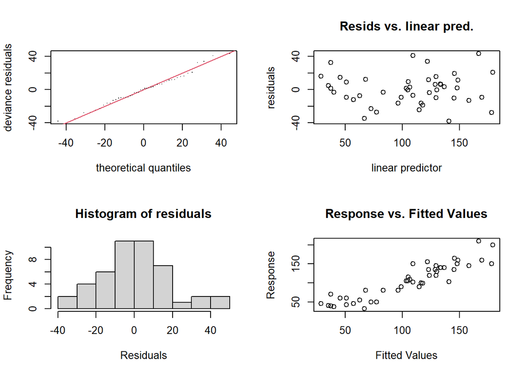

```
##
## Method: REML   Optimizer: outer newton
## full convergence after 8 iterations.
## Gradient range [-6.577002e-05,4.897667e-05]
## (score 192.1336 & scale 373.4297).
## Hessian positive definite, eigenvalue range [6.57576e-05,21.02078].
## Model rank =  8 / 8
##
## Basis dimension (k) checking results. Low p-value (k-index<1) may
## indicate that k is too low, especially if edf is close to k'.
##
##            k' edf k-index p-value
## s(SO2_z)  3.0 2.3    1.10    0.64
## s(PRES_z) 3.0 1.0    1.11    0.70
```

```r
gam.check(model_gam_final)
```

```r
concurvity(model_gam_final, full = TRUE)  # cek multikolinearitas
```

```
##               para  s(SO2_z) s(PRES_z)
## worst    0.9903225 0.2728093 0.2977575
## observed 0.9903225 0.2659839 0.1853273
## estimate 0.9903225 0.1632435 0.1956430
```

```r
# Uji asumsi residual
shapiro.test(residuals(model_gam_final))          # normalitas
```

```
##
##  Shapiro-Wilk normality test
##
## data:  residuals(model_gam_final)
## W = 0.98386, p-value = 0.7655
```

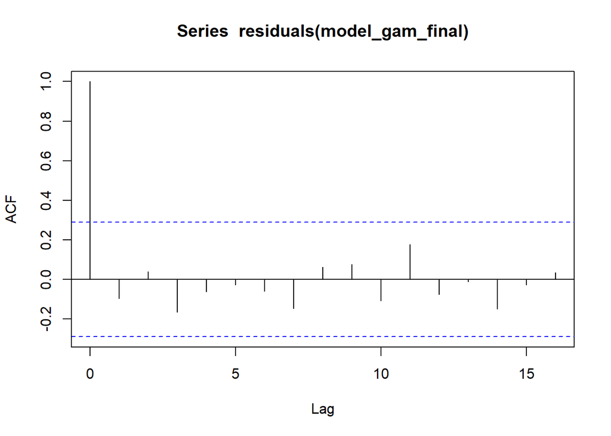

```r
acf(residuals(model_gam_final))                     # autokorelasi
```

```r
Box.test(residuals(model_gam_final), lag = 12, type = "Ljung-Box")
```

```
##
##  Box-Ljung test
##
## data:  residuals(model_gam_final)
## X-squared = 7.2006, df = 12, p-value = 0.8441
```

```r
bptest(residuals(model_gam_final) ~ fitted(model_gam_final))  # homoskedastisitas
```

```
##
##  studentized Breusch-Pagan test
##
## data:  residuals(model_gam_final) ~ fitted(model_gam_final)
## BP = 0.83627, df = 1, p-value = 0.3605
```

```r
pred_train_gam_final <- predict(model_gam_final, newdata = train_data)
pred_test_gam_final  <- predict(model_gam_final, newdata = test_data)
actual_train_gam_final   <- train_data$Case_ISPA
actual_test_gam_final    <- test_data$Case_ISPA

metrics_gam <- data.frame(
  Model = "GAM",
  RMSE_Test = sqrt(mean((actual_test_gam_final - pred_test_gam_final)^2)),
  MAE_Test  = mean(abs(actual_test_gam_final - pred_test_gam_final)),
  MAPE_Test = mean(abs((actual_test_gam_final - pred_test_gam_final) / actual_test_gam_final)) * 100,
  R2_Test   = 1 - sum((actual_test_gam_final - pred_test_gam_final)^2) / sum((actual_test_gam_final - mean(actual_test_gam_final))^2)
)
metrics_gam
```

| Model | RMSE_Test | MAE_Test | MAPE_Test | R2_Test |
| --- | --- | --- | --- | --- |
| GAM | 41.91017 | 29.88504 | 17.38063 | 0.003923905 |

# Bagian F. Model Development: ARIMAX

```r
library(forecast)
library(tseries)
```

## F.1. Uji Stasioneritas

```r
# Melakukan uji stasioneritas untuk menentukan nilai order pada model ARIMAX
adf.test(train_data$Case_ISPA)
```

```
##
##  Augmented Dickey-Fuller Test
##
## data:  train_data$Case_ISPA
## Dickey-Fuller = -2.5361, Lag order = 3, p-value = 0.3608
## alternative hypothesis: stationary
```

```r
train_diff <- diff(train_data$Case_ISPA)
adf.test(train_diff)
```

```
##
##  Augmented Dickey-Fuller Test
##
## data:  train_diff
## Dickey-Fuller = -3.8723, Lag order = 3, p-value = 0.02352
## alternative hypothesis: stationary
```

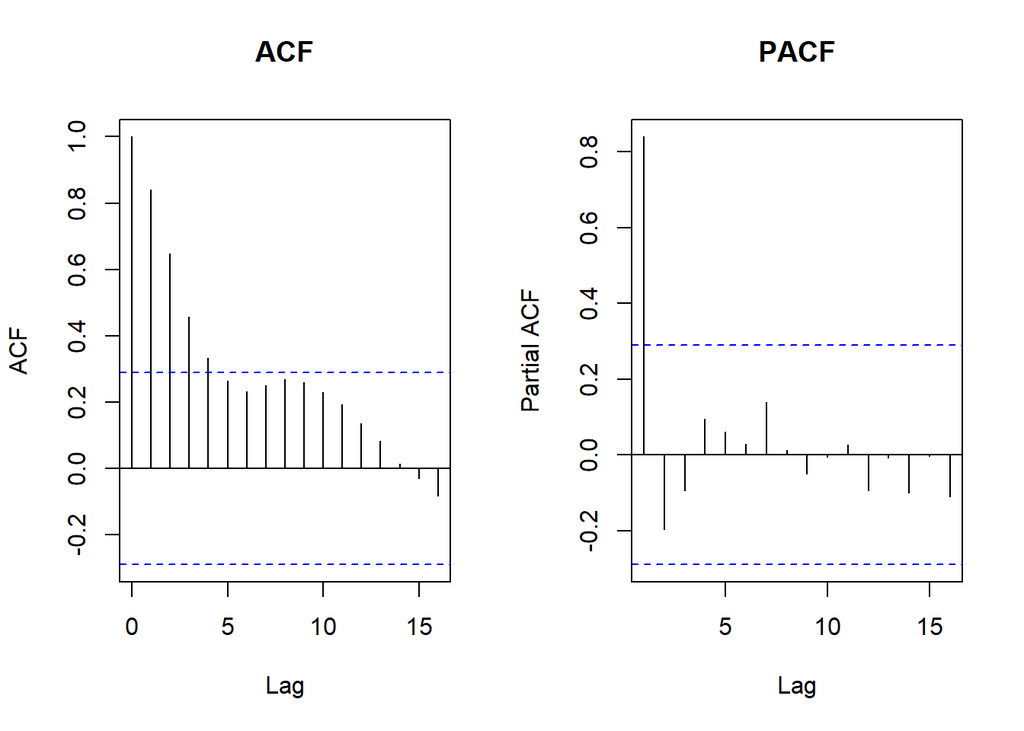

```r
par(mfrow = c(1, 2))
acf(train_data$Case_ISPA, main = "ACF")
pacf(train_data$Case_ISPA, main = "PACF")
```

```r
par(mfrow = c(1, 1))
```

## F.2. Kandidat Exogenous Variables

```r
xreg_fam1_train <- as.matrix(train_data[, c("PM2.5_z", "PM10_z", "NO2_z", "RAIN_z")])
xreg_fam1_test  <- as.matrix(test_data[,  c("PM2.5_z", "PM10_z", "NO2_z", "RAIN_z")])

xreg_fam2_train <- as.matrix(train_data[, c("PM2.5_z", "O3_z", "PRES_z")])
xreg_fam2_test  <- as.matrix(test_data[,  c("PM2.5_z", "O3_z", "PRES_z")])
```

## F.3. Pencarian Order ARIMA Terbaik

```r
ma1_fam1 <- Arima(train_data$Case_ISPA, order = c(1, 1, 0), xreg = xreg_fam1_train)
ma2_fam1 <- Arima(train_data$Case_ISPA, order = c(0, 1, 1), xreg = xreg_fam1_train)
ma3_fam1 <- Arima(train_data$Case_ISPA, order = c(1, 1, 1), xreg = xreg_fam1_train)
ma4_fam1 <- Arima(train_data$Case_ISPA, order = c(2, 1, 0), xreg = xreg_fam1_train)
ma5_fam1 <- Arima(train_data$Case_ISPA, order = c(0, 1, 0), xreg = xreg_fam1_train)

comparison_fam1 <- data.frame(
  Model = c("(1,1,0)", "(0,1,1)", "(1,1,1)", "(2,1,0)", "(0,1,0)"),
  AIC = c(AIC(ma1_fam1), AIC(ma2_fam1), AIC(ma3_fam1), AIC(ma4_fam1), AIC(ma5_fam1)),
  BIC = c(BIC(ma1_fam1), BIC(ma2_fam1), BIC(ma3_fam1), BIC(ma4_fam1), BIC(ma5_fam1))
)
comparison_fam1
```

| Model | AIC | BIC |
| --- | --- | --- |
| (1,1,0) | 408.3134 | 419.1534 |
| (0,1,1) | 408.2903 | 419.1302 |
| (1,1,1) | 406.9265 | 419.5731 |
| (2,1,0) | 410.1943 | 422.8409 |
| (0,1,0) | 406.5024 | 415.5357 |

```r
ma1_fam2 <- Arima(train_data$Case_ISPA, order = c(1, 1, 0), xreg = xreg_fam2_train)
ma2_fam2 <- Arima(train_data$Case_ISPA, order = c(0, 1, 1), xreg = xreg_fam2_train)
ma3_fam2 <- Arima(train_data$Case_ISPA, order = c(1, 1, 1), xreg = xreg_fam2_train)
ma4_fam2 <- Arima(train_data$Case_ISPA, order = c(2, 1, 0), xreg = xreg_fam2_train)
ma5_fam2 <- Arima(train_data$Case_ISPA, order = c(0, 1, 0), xreg = xreg_fam2_train)

comparison_fam2 <- data.frame(
  Model = c("(1,1,0)", "(0,1,1)", "(1,1,1)", "(2,1,0)", "(0,1,0)"),
  AIC = c(AIC(ma1_fam2), AIC(ma2_fam2), AIC(ma3_fam2), AIC(ma4_fam2), AIC(ma5_fam2)),
  BIC = c(BIC(ma1_fam2), BIC(ma2_fam2), BIC(ma3_fam2), BIC(ma4_fam2), BIC(ma5_fam2))
)
comparison_fam2
```

| Model | AIC | BIC |
| --- | --- | --- |
| (1,1,0) | 413.1420 | 422.1753 |
| (0,1,1) | 413.1475 | 422.1809 |
| (1,1,1) | 415.1228 | 425.9627 |
| (2,1,0) | 414.8453 | 425.6852 |
| (0,1,0) | 411.1763 | 418.4030 |

## F.4. Prediction Train dan Test Model FAM1 dan FAM2

```r
pred_train_110_fam1 <- fitted(ma1_fam1)
pred_train_011_fam1 <- fitted(ma2_fam1)
pred_train_111_fam1 <- fitted(ma3_fam1)
pred_train_210_fam1 <- fitted(ma4_fam1)
pred_train_010_fam1 <- fitted(ma5_fam1)
```

```r
pred_train_110_fam2 <- fitted(ma1_fam2)
pred_train_011_fam2 <- fitted(ma2_fam2)
pred_train_111_fam2 <- fitted(ma3_fam2)
pred_train_210_fam2 <- fitted(ma4_fam2)
pred_train_010_fam2 <- fitted(ma5_fam2)
```

```r
pred_test_110_fam1 <- forecast(
  ma1_fam1,
  h = nrow(test_data),
  xreg = xreg_fam1_test
)$mean

pred_test_011_fam1 <- forecast(
  ma2_fam1,
  h = nrow(test_data),
  xreg = xreg_fam1_test
)$mean

pred_test_111_fam1 <- forecast(
  ma3_fam1,
  h = nrow(test_data),
  xreg = xreg_fam1_test
)$mean

pred_test_210_fam1 <- forecast(
  ma4_fam1,
  h = nrow(test_data),
  xreg = xreg_fam1_test
)$mean

pred_test_010_fam1 <- forecast(
  ma5_fam1,
  h = nrow(test_data),
  xreg = xreg_fam1_test
)$mean
```

```r
pred_test_110_fam2 <- forecast(
  ma1_fam2,
  h = nrow(test_data),
  xreg = xreg_fam2_test
)$mean

pred_test_011_fam2 <- forecast(
  ma2_fam2,
  h = nrow(test_data),
  xreg = xreg_fam2_test
)$mean

pred_test_111_fam2 <- forecast(
  ma3_fam2,
  h = nrow(test_data),
  xreg = xreg_fam2_test
)$mean

pred_test_210_fam2 <- forecast(
  ma4_fam2,
  h = nrow(test_data),
  xreg = xreg_fam2_test
)$mean

pred_test_010_fam2 <- forecast(
  ma5_fam2,
  h = nrow(test_data),
  xreg = xreg_fam2_test
)$mean
```

```r
rmse <- function(actual, pred){
  sqrt(mean((actual-pred)^2))
}

mae <- function(actual,pred){
  mean(abs(actual-pred))
}

mape <- function(actual,pred){
  mean(abs((actual-pred)/actual))*100
}

r2 <- function(actual,pred){
  1-sum((actual-pred)^2)/
    sum((actual-mean(actual))^2)
}
```

## F.5. Evaluasi Model dengan berbagai Order dan Kandidat Variabel

```r
hasil_arima <- data.frame(

Model=c("(1,1,0)",
        "(0,1,1)",
        "(1,1,1)",
        "(2,1,0)",
        "(0,1,0)"),

Train_RMSE=c(
rmse(train_data$Case_ISPA,pred_train_110_fam1),
rmse(train_data$Case_ISPA,pred_train_011_fam1),
rmse(train_data$Case_ISPA,pred_train_111_fam1),
rmse(train_data$Case_ISPA,pred_train_210_fam1),
rmse(train_data$Case_ISPA,pred_train_010_fam1)
),

Train_MAE=c(
mae(train_data$Case_ISPA,pred_train_110_fam1),
mae(train_data$Case_ISPA,pred_train_011_fam1),
mae(train_data$Case_ISPA,pred_train_111_fam1),
mae(train_data$Case_ISPA,pred_train_210_fam1),
mae(train_data$Case_ISPA,pred_train_010_fam1)
),

Train_MAPE=c(
mape(train_data$Case_ISPA,pred_train_110_fam1),
mape(train_data$Case_ISPA,pred_train_011_fam1),
mape(train_data$Case_ISPA,pred_train_111_fam1),
mape(train_data$Case_ISPA,pred_train_210_fam1),
mape(train_data$Case_ISPA,pred_train_010_fam1)
),

Train_R2=c(
r2(train_data$Case_ISPA,pred_train_110_fam1),
r2(train_data$Case_ISPA,pred_train_011_fam1),
r2(train_data$Case_ISPA,pred_train_111_fam1),
r2(train_data$Case_ISPA,pred_train_210_fam1),
r2(train_data$Case_ISPA,pred_train_010_fam1)
),

Test_RMSE=c(
rmse(test_data$Case_ISPA,pred_test_110_fam1),
rmse(test_data$Case_ISPA,pred_test_011_fam1),
rmse(test_data$Case_ISPA,pred_test_111_fam1),
rmse(test_data$Case_ISPA,pred_test_210_fam1),
rmse(test_data$Case_ISPA,pred_test_010_fam1)
),

Test_MAE=c(
mae(test_data$Case_ISPA,pred_test_110_fam1),
mae(test_data$Case_ISPA,pred_test_011_fam1),
mae(test_data$Case_ISPA,pred_test_111_fam1),
mae(test_data$Case_ISPA,pred_test_210_fam1),
mae(test_data$Case_ISPA,pred_test_010_fam1)
),

Test_MAPE=c(
mape(test_data$Case_ISPA,pred_test_110_fam1),
mape(test_data$Case_ISPA,pred_test_011_fam1),
mape(test_data$Case_ISPA,pred_test_111_fam1),
mape(test_data$Case_ISPA,pred_test_210_fam1),
mape(test_data$Case_ISPA,pred_test_010_fam1)
),

Test_R2=c(
r2(test_data$Case_ISPA,pred_test_110_fam1),
r2(test_data$Case_ISPA,pred_test_011_fam1),
r2(test_data$Case_ISPA,pred_test_111_fam1),
r2(test_data$Case_ISPA,pred_test_210_fam1),
r2(test_data$Case_ISPA,pred_test_010_fam1)
)
)

hasil_arima
```

| Model | Train_RMSE | Train_MAE | Train_MAPE | Train_R2 | Test_RMSE | Test_MAE | Test_MAPE | Test_R2 |
| --- | --- | --- | --- | --- | --- | --- | --- | --- |
| (1,1,0) | 19.56023 | 14.70943 | 17.05931 | 0.8148009 | 70.17559 | 62.13661 | 37.02841 | -1.792710 |
| (0,1,1) | 19.55493 | 14.73261 | 17.10003 | 0.8149012 | 70.13963 | 62.08897 | 36.99807 | -1.789848 |
| (1,1,1) | 18.45313 | 14.39702 | 16.53901 | 0.8351719 | 69.88190 | 61.86312 | 36.89162 | -1.769383 |
| (2,1,0) | 19.53305 | 14.77642 | 17.25825 | 0.8153152 | 70.14723 | 62.10297 | 37.02736 | -1.790453 |
| (0,1,0) | 19.60244 | 14.64078 | 17.03030 | 0.8140007 | 70.57800 | 62.67310 | 37.40504 | -1.824831 |

```r
hasil_arima2 <- data.frame(

Model=c("(1,1,0)",
        "(0,1,1)",
        "(1,1,1)",
        "(2,1,0)",
        "(0,1,0)"),

Train_RMSE_2 =c(
rmse(train_data$Case_ISPA, pred_train_110_fam2),
rmse(train_data$Case_ISPA, pred_train_011_fam2),
rmse(train_data$Case_ISPA, pred_train_111_fam2),
rmse(train_data$Case_ISPA, pred_train_210_fam2),
rmse(train_data$Case_ISPA, pred_train_010_fam2)
),

Train_MAE_2 =c(
mae(train_data$Case_ISPA, pred_train_110_fam2),
mae(train_data$Case_ISPA, pred_train_011_fam2),
mae(train_data$Case_ISPA, pred_train_111_fam2),
mae(train_data$Case_ISPA, pred_train_210_fam2),
mae(train_data$Case_ISPA, pred_train_010_fam2)
),

Train_MAPE_2 =c(
mape(train_data$Case_ISPA, pred_train_110_fam2),
mape(train_data$Case_ISPA, pred_train_011_fam2),
mape(train_data$Case_ISPA, pred_train_111_fam2),
mape(train_data$Case_ISPA, pred_train_210_fam2),
mape(train_data$Case_ISPA, pred_train_010_fam2)
),

Train_R2_2=c(
r2(train_data$Case_ISPA, pred_train_110_fam2),
r2(train_data$Case_ISPA, pred_train_011_fam2),
r2(train_data$Case_ISPA, pred_train_111_fam2),
r2(train_data$Case_ISPA, pred_train_210_fam2),
r2(train_data$Case_ISPA, pred_train_010_fam2)
),

Test_RMSE_2=c(
rmse(test_data$Case_ISPA, pred_test_110_fam2),
rmse(test_data$Case_ISPA, pred_test_011_fam2),
rmse(test_data$Case_ISPA, pred_test_111_fam2),
rmse(test_data$Case_ISPA, pred_test_210_fam2),
rmse(test_data$Case_ISPA, pred_test_010_fam2)
),

Test_MAE_2=c(
mae(test_data$Case_ISPA, pred_test_110_fam2),
mae(test_data$Case_ISPA, pred_test_011_fam2),
mae(test_data$Case_ISPA, pred_test_111_fam2),
mae(test_data$Case_ISPA, pred_test_210_fam2),
mae(test_data$Case_ISPA, pred_test_010_fam2)
),

Test_MAPE_2=c(
mape(test_data$Case_ISPA, pred_test_110_fam2),
mape(test_data$Case_ISPA, pred_test_011_fam2),
mape(test_data$Case_ISPA, pred_test_111_fam2),
mape(test_data$Case_ISPA, pred_test_210_fam2),
mape(test_data$Case_ISPA, pred_test_010_fam2)
),

Test_R2_2=c(
r2(test_data$Case_ISPA, pred_test_110_fam2),
r2(test_data$Case_ISPA, pred_test_011_fam2),
r2(test_data$Case_ISPA, pred_test_111_fam2),
r2(test_data$Case_ISPA, pred_test_210_fam2),
r2(test_data$Case_ISPA, pred_test_010_fam2)
)
)

hasil_arima2
```

| Model | Train_RMSE_2 | Train_MAE_2 | Train_MAPE_2 | Train_R2_2 | Test_RMSE_2 | Test_MAE_2 | Test_MAPE_2 | Test_R2_2 |
| --- | --- | --- | --- | --- | --- | --- | --- | --- |
| (1,1,0) | 21.10306 | 15.76754 | 17.72469 | 0.7844333 | 48.72853 | 37.88657 | 21.61502 | -0.3465432 |
| (0,1,1) | 21.10442 | 15.76649 | 17.71731 | 0.7844055 | 48.80239 | 37.96046 | 21.65419 | -0.3506287 |
| (1,1,1) | 21.09829 | 15.77174 | 17.60370 | 0.7845307 | 49.22794 | 38.39282 | 21.88281 | -0.3742857 |
| (2,1,0) | 21.03046 | 15.70736 | 17.54353 | 0.7859139 | 47.58138 | 36.79588 | 21.04094 | -0.2838896 |
| (0,1,0) | 21.11131 | 15.75302 | 17.66638 | 0.7842646 | 49.10644 | 38.26758 | 21.81880 | -0.3675105 |

## F.6. Model ARIMAX Final

```r
model_arimax_final <- Arima(
  train_data$Case_ISPA,
  order = c(2, 1, 0),
  xreg = xreg_fam2_train
)

summary(model_arimax_final)
```

```
## Series: train_data$Case_ISPA
## Regression with ARIMA(2,1,0) errors
##
## Coefficients:
##          ar1     ar2   PM2.5_z     O3_z  PRES_z
##       0.0247  0.0822  -15.0055  21.0230  8.8201
## s.e.  0.1570  0.1505    7.3658   8.2772  3.4474
##
## sigma^2 = 508.6:  log likelihood = -201.42
## AIC=414.85   AICc=417.06   BIC=425.69
##
## Training set error measures:
##                    ME     RMSE      MAE       MPE     MAPE      MASE       ACF1
## Training set 2.347402 21.03046 15.70736 0.2699089 17.54353 0.9203654 0.00268287
```

```r
coeftest(model_arimax_final)
```

```
##
## z test of coefficients:
##
##           Estimate Std. Error z value Pr(>|z|)
## ar1       0.024682   0.156979  0.1572  0.87506
## ar2       0.082195   0.150459  0.5463  0.58486
## PM2.5_z -15.005532   7.365808 -2.0372  0.04163 *
## O3_z     21.022983   8.277187  2.5399  0.01109 *
## PRES_z    8.820057   3.447357  2.5585  0.01051 *
## ---
## Signif. codes:  0 '***' 0.001 '**' 0.01 '*' 0.05 '.' 0.1 ' ' 1
```

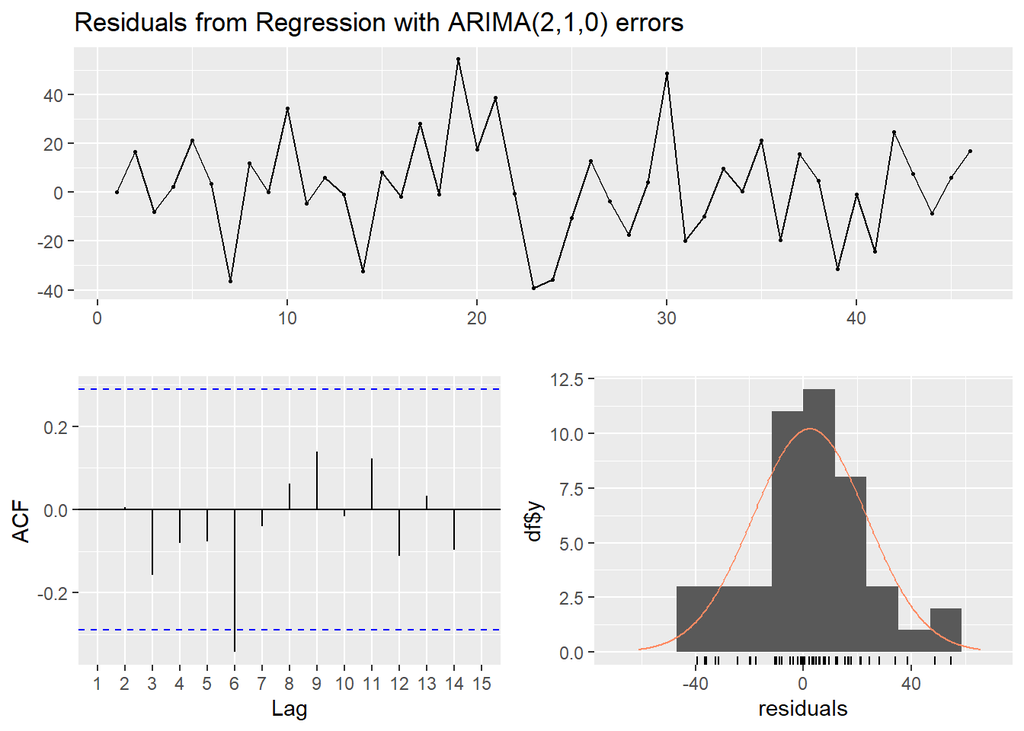

```
##
##  Ljung-Box test
##
## data:  Residuals from Regression with ARIMA(2,1,0) errors
## Q* = 9.8849, df = 7, p-value = 0.1952
##
## Model df: 2.   Total lags used: 9
```

```r
checkresiduals(model_arimax_final)
```

```r
pred_arimax <- forecast(model_arimax_final, h = nrow(test_data),
                         xreg = xreg_fam2_test)$mean

# Evaluasi Training & Testing
pred_train_arimax <- fitted(model_arimax_final)
actual_train_arimax <- train_data$Case_ISPA
pred_test_arimax  <- as.numeric(pred_arimax)
actual_test_arimax <- test_data$Case_ISPA

metrics_arimax <- data.frame(
  Model = "ARIMAX",
  RMSE_Test = sqrt(mean((actual_test_arimax - pred_test_arimax)^2)),
  MAE_Test  = mean(abs(actual_test_arimax - pred_test_arimax)),
  MAPE_Test = mean(abs((actual_test_arimax - pred_test_arimax) / actual_test_arimax)) * 100,
  R2_Test   = 1 - sum((actual_test_arimax - pred_test_arimax)^2) / sum((actual_test_arimax - mean(actual_test_arimax))^2)
)

data.frame(
  RMSE_Train = sqrt(mean((actual_train_arimax - pred_train_arimax)^2)),
  MAE_Train  = mean(abs(actual_train_arimax - pred_train_arimax)),
  MAPE_Train = mean(abs((actual_train_arimax - pred_train_arimax) / actual_train_arimax)) * 100,
  R2_Train   = 1 - sum((actual_train_arimax - pred_train_arimax)^2) / sum((actual_train_arimax - mean(actual_train_arimax))^2),
  RMSE_Test  = metrics_arimax$RMSE_Test,
  MAE_Test   = metrics_arimax$MAE_Test,
  MAPE_Test  = metrics_arimax$MAPE_Test,
  R2_Test    = metrics_arimax$R2_Test
)
```

| RMSE_Train | MAE_Train | MAPE_Train | R2_Train | RMSE_Test | MAE_Test | MAPE_Test | R2_Test |
| --- | --- | --- | --- | --- | --- | --- | --- |
| 21.03046 | 15.70736 | 17.54353 | 0.7859139 | 47.58138 | 36.79588 | 21.04094 | -0.2838896 |